# Sensitivity analysis of model parameters

2025-07-11

### Model

$$B = d \left [ \frac{H}{2} \left ( A_{basal} + A_{half} \right ) \right
]^{z},$$
where $B$ is the biomass calculated by the allometric equation, $d$ is the bulk density of the plant species, $H$ is the measured height of the plant, $A_{basal}$ and $A_{half}$ are the basal area and the area at half the height of the plant, respectively; and $z$ is the power coefficient of a power law.

### Problem

In Perronne et al. (2020), the authors assign a value of 1.96 to $d$ and a value of $2/3$ to $z$; however, we do not know how those parameters interact with each other.

### Approach

To solve this, we will perform a sensitivity analysis in which we modify the values of $d$ and $z$ within a certain range. Importantly, to simplify the allometric equation and do a clear sensitivity analyses that works independently of the field data, we opt to include the parameter $x$ as:

$$x = \left [ \frac{H}{2} \left ( A_{basal} + A_{half} \right ) \right ],$$
meaning that all allometric measurements are summarized now by $x$. Thus, the equation used for our sensitivity analysis is the following:

$$B = dx^{z}$$

### Distribution of $X$ and outliers management

First, we have to take a look to an histogram and a boxplot of $X$ distribution:

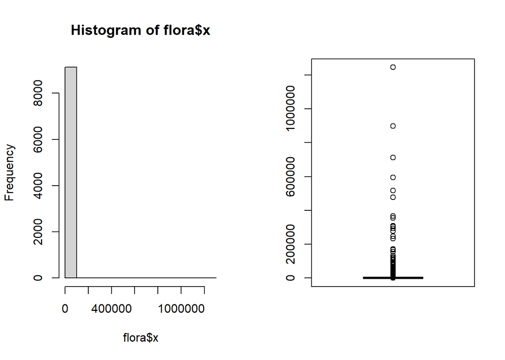

As we can see, there is a problem with $X$ outliers. If we take a look to the quantiles:

- 0%: 7.0685835^{-4}
- 25%: 2.144942
- 50%: 25.9475918
- 75%: 108.2317939
- 100%: 1.2456886^{6}

- 80%: 156.8141681
- 85%: 259.9188828
- 90%: 506.7231871
- 95%: 1720.6750364
- 96%: 2564.7839902
- 97%: 4480.2867014
- 98%: 9403.5206882
- 99%: 2.0050795^{4}

The distribution of data once we reject different levels of outliers would be as follow:

[figure not shown]

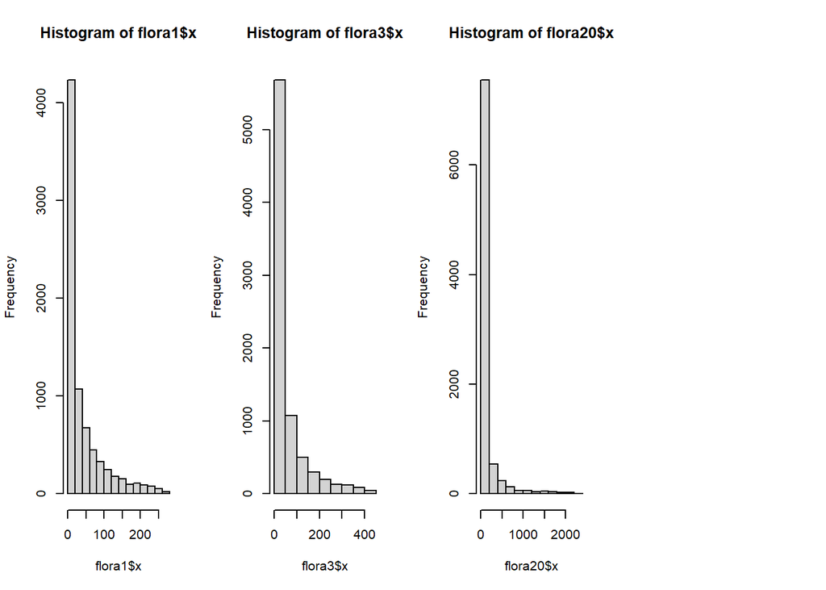

*Boxplots and histograms of X*

#### Questions about outliers

- What is the ecological meaning of the outliers? And what would be the meaning of their removal?
- If we do remove outliers, which group of outliers should we take out?

## $d$ and $z$ influence on $x$

At this point, we assign the following values to the different parameters in the model:

- $d$. 1.96 is the value proposed by Perronne et al. (2020). By the structure of the model, we know that $d$ will have an influence on the scale of biomass. Hence, we will only apply half of that value and its double. Therefore: for $d$, values of 0.98, 1.96, 3.92;
- $x$. We have seen how distribution of $x$ is influenced by the pressence of outliers. We will have 3 groups of $x$. 1) for $x1$ (without outliers), 0, 25, 50, 75, 100, 125, 150, 175, 200, 225, 250; 2) for $xsmall$ (for the smallest values of x, going from the minimum value until the 25% quantile), 0, 0.15, 0.3, 0.45, 0.6, 0.75, 0.9, 1.05, 1.2, 1.35, 1.5, 1.65, 1.8, 1.95; for $xout$, outliers of $x$ (outliers).
- $z$. The value proposed for $z$ by the authors is 2/3. Since it is a power coefficient, we need to apply more values of $z$ in order to understand its influence on the biomass. Hence, we will have a list of values: 0.1, 0.11, 0.12, 0.13, 0.14, 0.15, 0.16, 0.17, 0.18, 0.19, 0.2, 0.21, 0.22, 0.23, 0.24, 0.25, 0.26, 0.27, 0.28, 0.29, 0.3, 0.31, 0.32, 0.33, 0.34, 0.35, 0.36, 0.37, 0.38, 0.39, 0.4, 0.41, 0.42, 0.43, 0.44, 0.45, 0.46, 0.47, 0.48, 0.49, 0.5, 0.51, 0.52, 0.53, 0.54, 0.55, 0.56, 0.57, 0.58, 0.59, 0.6, 0.61, 0.62, 0.63, 0.64, 0.65, 0.66, 0.67, 0.68, 0.69, 0.7, 0.71, 0.72, 0.73, 0.74, 0.75, 0.76, 0.77, 0.78, 0.79, 0.8, 0.81, 0.82, 0.83, 0.84, 0.85, 0.86, 0.87, 0.88, 0.89, 0.9, 0.91, 0.92, 0.93, 0.94, 0.95, 0.96, 0.97, 0.98, 0.99, 1.

### Dataviz

Now, some visualizations to understand the relationship between the different parameters.

#### $x$ and $z$

The relationship between $x$ and $z$ for values of $d$ looks like this:

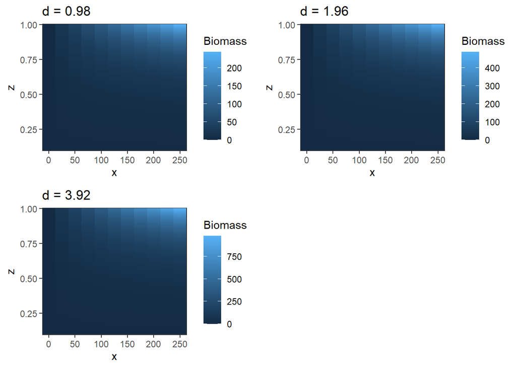

From these graphs we can conclude that: $d$ have an effect on magnitude of biomass and $z$ increases biomass proportionally to $X$. Since we do not want to exactly know the absolute values of biomass, but rather the relative contribution of each species, $d$ value is not as relevant. However, the relationship between $z$ and $x$ deserves further consideration. In this regard, we can first take a look to $x$ distribution.

### Expression “X” and its interaction with $Z$

To check $z$ influence on $x$ we can display a graph where we can see how biomass change as a function of changes in $z$, for different values of $x$. In the following graphs we can see:

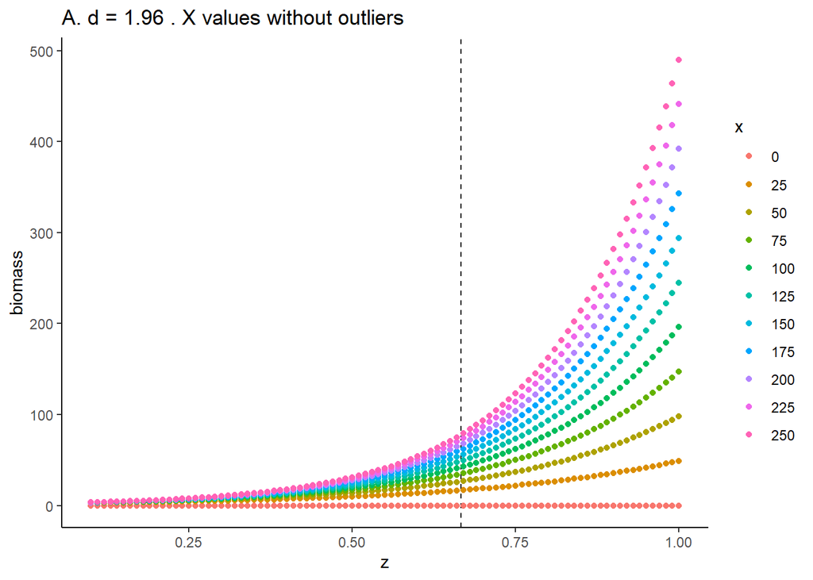

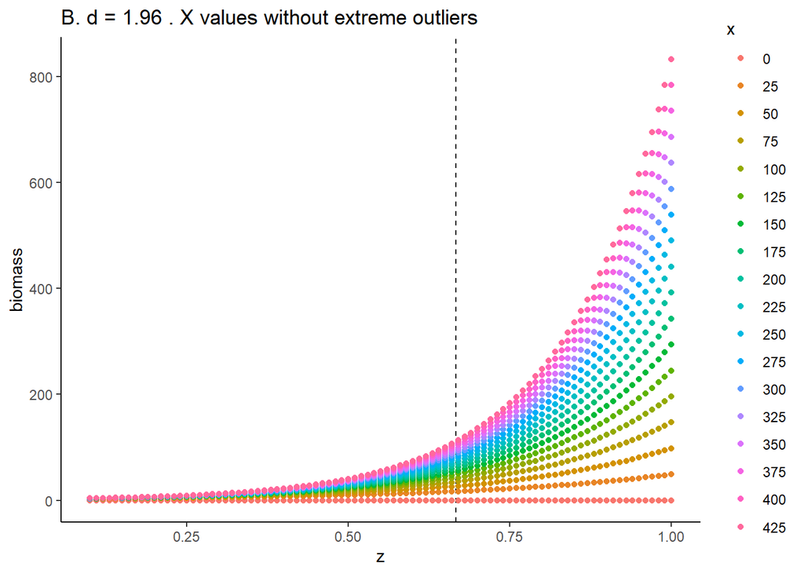

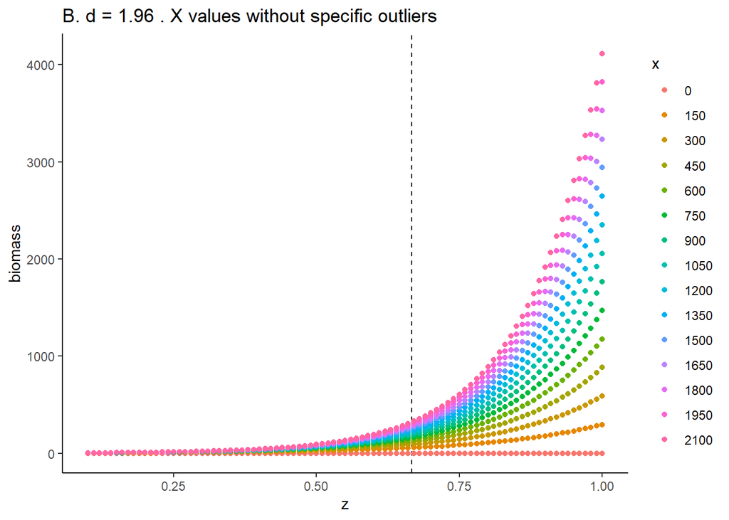

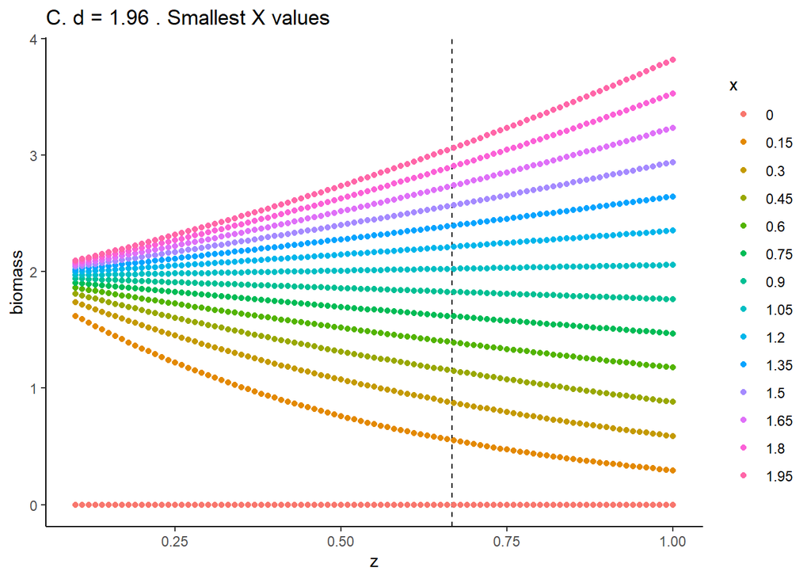

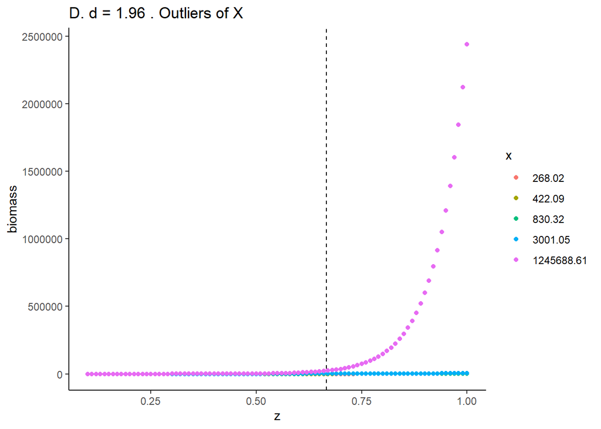

## Conclusions

- $d$ = 1.96. $d$ affects the magnitude (scale) of biomass, no matter the size of the species. It would influence the fact that we got mg, cg, g or kg of biomass. Since we are itnerested in the relative values, it is no so relevant.
- $z$ = 2/3. If it were higher, the differences estimated for biomass between small species and big species would be “too much” (when is too much?). If it were lower, some differences wouldn’t be appreciated. hence, either we do not use a $z$ value or we use the proposed value.

## Further questions

- Based on z influence on X and on data distribution, which outliers should we take out? Extreme outliers or just outliers?
- If we do remove outliers, which ecological/conceptual implications would have?

### References

Perronne, R., F. Jabot, and J. Pottier. 2020. [Inter- and intraspecific variability of plant individual growth and its role on species ranking in grasslands](https://doi.org/10.1093/jpe/rtaa021). Journal of Plant Ecology 13:378–386.